# Airline On-Time Performance Data Exploration

## Introduction

> This dataset reports flights in the USA, including carriers, arrival and departure delays, and reasons for delays, from 1987 to 2008. To hold the analysis, 100K rows of data were randomly selected from each of the datasets of corresponding years. [Data Source](https://community.amstat.org/jointscsg-section/dataexpo/dataexpo2009)

## Preliminary Wrangling

```python
# import all packages and set plots to be embedded inline
import os
import numpy as np
import pandas as pd
import matplotlib.pyplot as plt
import seaborn as sb

%matplotlib inline
```

### Gather data

> The data is downloaded from the site: https://community.amstat.org/jointscsg-section/dataexpo/dataexpo2009

> As there are separate datasets for each year, it was necessary merge them to get one general one

```python
# Load a sample dataset
df_1987 = pd.read_csv("../data/dataverse_files/1987.csv")
```

```python
# Print the first 5 lines
df_1987.info()
```

```
<class 'pandas.core.frame.DataFrame'>
RangeIndex: 1311826 entries, 0 to 1311825
Data columns (total 29 columns):
 #   Column             Non-Null Count    Dtype
---  ------             --------------    -----
 0   Year               1311826 non-null  int64
 1   Month              1311826 non-null  int64
 2   DayofMonth         1311826 non-null  int64
 3   DayOfWeek          1311826 non-null  int64
 4   DepTime            1292141 non-null  float64
 5   CRSDepTime         1311826 non-null  int64
 6   ArrTime            1288326 non-null  float64
 7   CRSArrTime         1311826 non-null  int64
 8   UniqueCarrier      1311826 non-null  object
 9   FlightNum          1311826 non-null  int64
```

[output cut: 21 more lines]

```python
df = pd.DataFrame()
```

```python
files = os.listdir("../data/dataverse_files")
files
```

```
['1987.csv',
 '1988.csv',
 '1989.csv',
 '1990.csv',
 '1991.csv',
 '1992.csv',
 '1993.csv',
 '1994.csv',
 '1995.csv',
 '1996.csv',
 '1997.csv',
 '1998.csv',
 '1999.csv',
 '2000.csv',
 '2001.csv',
 '2002.csv',
 '2003.csv',
 '2004.csv',
 '2005.csv',
 '2006.csv',
 '2007.csv',
 '2008.csv']
```

```python
# get the file names using listdir function
for file in files:
    # load a file into a temporary dataset extracting 100K sample rows
    temp_df = pd.read_csv("../data/dataverse_files/" + file, encoding = "latin-1").sample(int(1e5))
    df = pd.concat([df, temp_df], axis=0)

    # print the information message
    print(f"Successfully loaded the file {file}")
```

```
Successfully loaded the file 1987.csv
Successfully loaded the file 1988.csv
Successfully loaded the file 1989.csv
Successfully loaded the file 1990.csv
Successfully loaded the file 1991.csv
Successfully loaded the file 1992.csv
Successfully loaded the file 1993.csv
Successfully loaded the file 1994.csv
Successfully loaded the file 1995.csv
Successfully loaded the file 1996.csv
Successfully loaded the file 1997.csv
Successfully loaded the file 1998.csv
Successfully loaded the file 1999.csv
Successfully loaded the file 2000.csv
Successfully loaded the file 2001.csv
Successfully loaded the file 2002.csv
```

```
Successfully loaded the file 2003.csv
Successfully loaded the file 2004.csv
Successfully loaded the file 2005.csv
Successfully loaded the file 2006.csv
Successfully loaded the file 2007.csv
Successfully loaded the file 2008.csv
```

```python
# save the dataframe into a csv file
df.to_csv("merged_data.csv");
```

### Assess Data

```python
df = pd.read_csv("../data/merged_data.csv")
```

```python
df.head()
```

|  | Unnamed: 0 | Year | Month | DayofMonth | DayOfWeek | DepTime | CRSDepTime | ArrTime | CRSArrTime | UniqueCarrier | ... | TaxiIn | TaxiOut | Cancelled | CancellationCode | Diverted | CarrierDelay | WeatherDelay | NASDelay | SecurityDelay | LateAircraftDelay |
| --- | --- | --- | --- | --- | --- | --- | --- | --- | --- | --- | --- | --- | --- | --- | --- | --- | --- | --- | --- | --- | --- |
| 0 | 549481 | 1987 | 11 | 2 | 1 | 2045.0 | 2030 | 2.0 | 2350 | WN | ... | NaN | NaN | 0 | NaN | 0 | NaN | NaN | NaN | NaN | NaN |
| 1 | 477493 | 1987 | 11 | 6 | 5 | 1645.0 | 1645 | 1747.0 | 1752 | TW | ... | NaN | NaN | 0 | NaN | 0 | NaN | NaN | NaN | NaN | NaN |
| 2 | 1214811 | 1987 | 12 | 16 | 3 | 2018.0 | 2011 | 2109.0 | 2105 | AA | ... | NaN | NaN | 0 | NaN | 0 | NaN | NaN | NaN | NaN | NaN |
| 3 | 49118 | 1987 | 10 | 4 | 7 | 1829.0 | 1830 | 1934.0 | 1946 | UA | ... | NaN | NaN | 0 | NaN | 0 | NaN | NaN | NaN | NaN | NaN |
| 4 | 1015361 | 1987 | 12 | 7 | 1 | 735.0 | 735 | 915.0 | 850 | NW | ... | NaN | NaN | 0 | NaN | 0 | NaN | NaN | NaN | NaN | NaN |

5 rows × 30 columns

```python
# drop the mixed index column
df.drop("Unnamed: 0", axis=1, inplace=True)
```

```python
# check the new shape of the dataset
df.shape
```

```
(2200000, 29)
```

```python
# check the datatypes and null values
df.info(show_counts=True)
```

```
<class 'pandas.core.frame.DataFrame'>
RangeIndex: 2200000 entries, 0 to 2199999
Data columns (total 29 columns):
 #   Column             Non-Null Count    Dtype
---  ------             --------------    -----
 0   Year               2200000 non-null  int64
 1   Month              2200000 non-null  int64
 2   DayofMonth         2200000 non-null  int64
 3   DayOfWeek          2200000 non-null  int64
 4   DepTime            2159227 non-null  float64
 5   CRSDepTime         2200000 non-null  int64
 6   ArrTime            2154176 non-null  float64
 7   CRSArrTime         2200000 non-null  int64
 8   UniqueCarrier      2200000 non-null  object
 9   FlightNum          2200000 non-null  int64
```

[output cut: 21 more lines]

### What is the structure of your dataset?

> The whole dataset is distributed among years each one containing 29 columns and millions of rows.

### What is/are the main feature(s) of interest in your dataset?

> The main features of interest in the dataset are the increase/decrease flight trends over the years, also the relationships between delay times, and scheduled hours.

### What features in the dataset do you think will help support your investigation into your feature(s) of interest?

> Arrival and Departure Delay columns, as well as date, month, and weekday columns.

## Univariate Exploration

> In this section, distributions of individual variables were investigated.

### Question #1

> In which month the most number of flights occurred during the period of 1987-2008?

### Visualisation

```python
# get the mount count
month_count = df['Month'].value_counts().sort_index()
month_labels = month_count.index

# calculate the relative frequency
month_total = month_count.sum()

max_value = month_count.values[0] / month_total

tick_props = np.arange(0, max_value + 0.04, 0.02)
tick_names = ['{:0.2f}'.format(v) for v in tick_props]
```

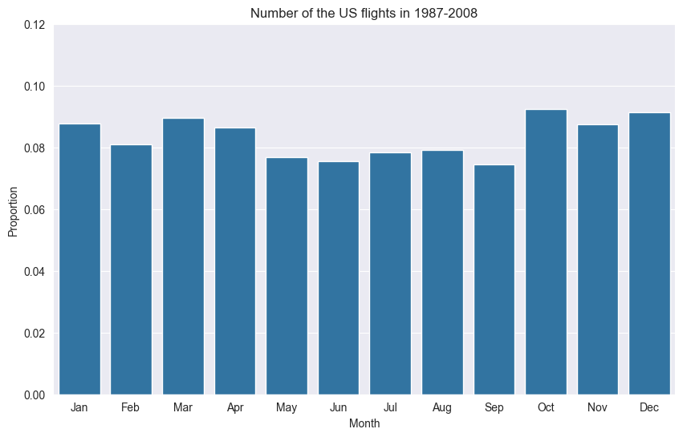

```python
import calendar
# get month labels
abbr_month = [calendar.month_abbr[label] for label in month_labels.values]

base_color = sb.color_palette()[0]

# set the figure size
plt.figure(figsize=(10, 6))

# seaborn countplot
sb.countplot(data=df, x="Month", color=base_color, order=month_labels)

plt.title("Number of the US flights in 1987-2008")

# set the custom ticks
plt.yticks(tick_props * month_total, tick_names)
plt.xticks(np.arange(0, 12, 1), abbr_month)

plt.ylabel("Proportion");
```

### Observation

> It is notable that the number of flights were genuinely close to each other, October containing the most.

### Question #2

> What is the distribution of the distance passed in flights during the period?

### Visualisation

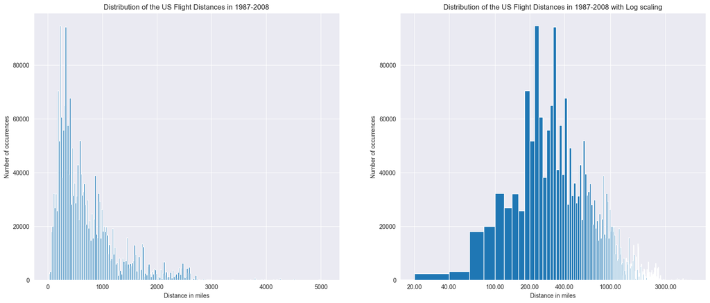

```python
plt.figure(figsize = [20, 8])

# First plot
plt.subplot(1, 2, 1)

# set the bin size
bins = np.arange(0, df['Distance'].max() + 100, 20)
plt.hist(x=df['Distance'], bins=bins)

# title and labels
plt.xlabel("Distance in miles")
plt.ylabel("Number of occurrences")

plt.title("Distribution of the US Flight Distances in 1987-2008")
# Second plot

plt.subplot(1, 2, 2)
plt.hist(x=df['Distance'], bins=bins)

# x-axis log scaling
plt.xscale("log")

# set up the ticks values and names
xtick_values = [20, 40, 100, 200, 400, 1000, 3000]
xtick_names = ['{:0.2f}'.format(value) for value in xtick_values]

# apply the ticks
plt.xticks(ticks=xtick_values, labels=xtick_names)

plt.xlabel("Distance in miles")
plt.ylabel("Number of occurrences")

plt.title("Distribution of the US Flight Distances in 1987-2008 with Log scaling");
```

```python
df[df['Distance'] == df['Distance'].max()]
```

|  | Year | Month | DayofMonth | DayOfWeek | DepTime | CRSDepTime | ArrTime | CRSArrTime | UniqueCarrier | FlightNum | ... | TaxiIn | TaxiOut | Cancelled | CancellationCode | Diverted | CarrierDelay | WeatherDelay | NASDelay | SecurityDelay | LateAircraftDelay |
| --- | --- | --- | --- | --- | --- | --- | --- | --- | --- | --- | --- | --- | --- | --- | --- | --- | --- | --- | --- | --- | --- |
| 23938 | 1987 | 10 | 8 | 4 | 1842.0 | 1800 | 2258.0 | 2230 | CO | 15 | ... | NaN | NaN | 0 | NaN | 0 | NaN | NaN | NaN | NaN | NaN |
| 36216 | 1987 | 10 | 16 | 5 | 812.0 | 815 | 2326.0 | 2330 | CO | 16 | ... | NaN | NaN | 0 | NaN | 0 | NaN | NaN | NaN | NaN | NaN |
| 51005 | 1987 | 12 | 26 | 6 | 1705.0 | 1700 | 703.0 | 700 | PA (1) | 18 | ... | NaN | NaN | 0 | NaN | 0 | NaN | NaN | NaN | NaN | NaN |
| 56344 | 1987 | 10 | 14 | 3 | 811.0 | 815 | 2329.0 | 2330 | CO | 16 | ... | NaN | NaN | 0 | NaN | 0 | NaN | NaN | NaN | NaN | NaN |
| 57827 | 1987 | 10 | 15 | 4 | 816.0 | 815 | 2331.0 | 2330 | CO | 16 | ... | NaN | NaN | 0 | NaN | 0 | NaN | NaN | NaN | NaN | NaN |

5 rows × 29 columns

### Observation

> We can see that the most common distance passed among the values lies between the range of about 200 and 800 miles.

### Question #3

> What are the top 7 destinations visited during this period?

### Visualisation

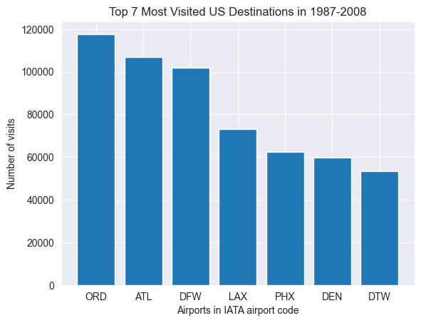

```python
# get top 7 destinations
top7_dest = df["Dest"].value_counts()[:7]

# plt bar plot
plt.bar(x=top7_dest.index, height=top7_dest.values)

# title and labels
plt.title("Top 7 Most Visited US Destinations in 1987-2008")
plt.xlabel("Airports in IATA airport code")
plt.ylabel("Number of visits");
```

### Observation

> According to the bar chart obtained, the Chicago O'Hare International Airport (ORD) had the most number of visits over the period.

### Question #4

> What are the distributions of arrival and departure delays in minutes?

### Visualisation

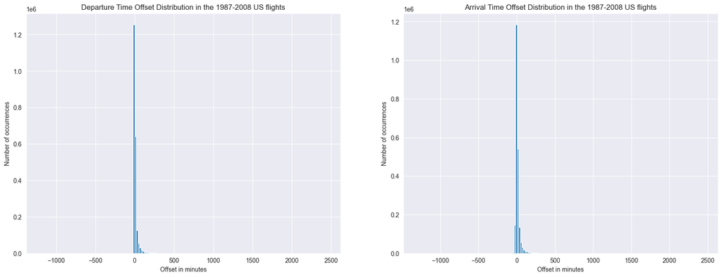

```python
# set the figure size
plt.figure(figsize = [20, 7])

# subplot 1
plt.subplot(1, 2, 1)

# set the bin size
bins = np.arange(df['DepDelay'].min(), df['DepDelay'].max(), 20)

# plot the histogram
plt.hist(df["DepDelay"].dropna(), bins=bins)

# title and labels
plt.title("Departure Time Offset Distribution in the 1987-2008 US flights")
plt.xlabel("Offset in minutes")
plt.ylabel("Number of occurrences")

# subplot 2
plt.subplot(1, 2, 2)

# set the bin size
bins = np.arange(df['ArrDelay'].min(), df['ArrDelay'].max(), 20)
plt.hist(df["ArrDelay"].dropna(), bins=bins)

# title and labels
plt.title("Arrival Time Offset Distribution in the 1987-2008 US flights")
plt.xlabel("Offset in minutes")
plt.ylabel("Number of occurrences");
```

```python
# Check out negative values: early arrivals
df[df['ArrDelay'] < 0]
```

|  | Year | Month | DayofMonth | DayOfWeek | DepTime | CRSDepTime | ArrTime | CRSArrTime | UniqueCarrier | FlightNum | ... | TaxiIn | TaxiOut | Cancelled | CancellationCode | Diverted | CarrierDelay | WeatherDelay | NASDelay | SecurityDelay | LateAircraftDelay |
| --- | --- | --- | --- | --- | --- | --- | --- | --- | --- | --- | --- | --- | --- | --- | --- | --- | --- | --- | --- | --- | --- |
| 1 | 1987 | 11 | 6 | 5 | 1645.0 | 1645 | 1747.0 | 1752 | TW | 561 | ... | NaN | NaN | 0 | NaN | 0 | NaN | NaN | NaN | NaN | NaN |
| 3 | 1987 | 10 | 4 | 7 | 1829.0 | 1830 | 1934.0 | 1946 | UA | 301 | ... | NaN | NaN | 0 | NaN | 0 | NaN | NaN | NaN | NaN | NaN |
| 11 | 1987 | 12 | 30 | 3 | 1044.0 | 1044 | 1143.0 | 1149 | EA | 658 | ... | NaN | NaN | 0 | NaN | 0 | NaN | NaN | NaN | NaN | NaN |
| 14 | 1987 | 10 | 18 | 7 | 1555.0 | 1555 | 1643.0 | 1646 | AA | 393 | ... | NaN | NaN | 0 | NaN | 0 | NaN | NaN | NaN | NaN | NaN |
| 18 | 1987 | 12 | 5 | 6 | 1210.0 | 1210 | 1340.0 | 1357 | CO | 1059 | ... | NaN | NaN | 0 | NaN | 0 | NaN | NaN | NaN | NaN | NaN |
| ... | ... | ... | ... | ... | ... | ... | ... | ... | ... | ... | ... | ... | ... | ... | ... | ... | ... | ... | ... | ... | ... |
| 2199993 | 2008 | 2 | 17 | 7 | 929.0 | 935 | 1043.0 | 1048 | US | 917 | ... | 5.0 | 12.0 | 0 | NaN | 0 | NaN | NaN | NaN | NaN | NaN |
| 2199995 | 2008 | 4 | 3 | 4 | 1205.0 | 1209 | 1246.0 | 1250 | OO | 5708 | ... | 4.0 | 7.0 | 0 | NaN | 0 | NaN | NaN | NaN | NaN | NaN |
| 2199996 | 2008 | 4 | 1 | 2 | 920.0 | 932 | 1026.0 | 1042 | OO | 5481 | ... | 8.0 | 6.0 | 0 | NaN | 0 | NaN | NaN | NaN | NaN | NaN |
| 2199997 | 2008 | 4 | 16 | 3 | 1503.0 | 1510 | 1753.0 | 1758 | XE | 2847 | ... | 10.0 | 17.0 | 0 | NaN | 0 | NaN | NaN | NaN | NaN | NaN |
| 2199999 | 2008 | 1 | 2 | 3 | 1018.0 | 1015 | 1751.0 | 1753 | DL | 1781 | ... | 4.0 | 22.0 | 0 | NaN | 0 | NaN | NaN | NaN | NaN | NaN |

1005590 rows × 29 columns

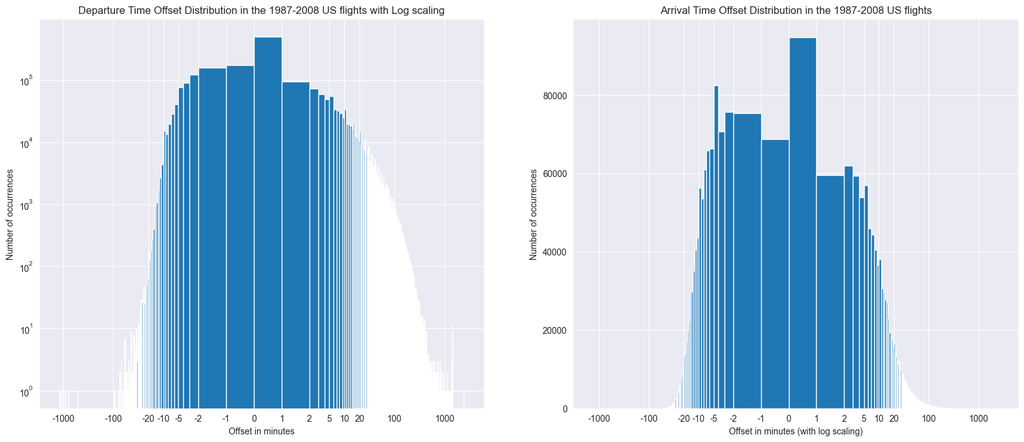

```python
plt.figure(figsize = [20, 8])
# Departure Delay
plt.subplot(1, 2, 1)

# Set bins for each minute
bins = np.arange(df['DepDelay'].min(), df['DepDelay'].max()+5, 1)

plt.hist(df['DepDelay'], bins=bins)

# sb.histplot(df['DepDelay'], bins=bins)

plt.title("Departure Time Offset Distribution in the 1987-2008 US flights with Log scaling")
plt.xlabel("Offset in minutes")
plt.ylabel("Number of occurrences")

plt.xscale("symlog")
plt.yscale("log")

# set up the ticks values and names
xtick_values = [-1000, -100, -10, -20, -5, -2, -1, 0, 1, 2, 5, 10, 20, 100, 1000]
xtick_names = ['{}'.format(value) for value in xtick_values]

# apply the ticks
plt.xticks(ticks=xtick_values, labels=xtick_names)

# Arrival Delay
plt.subplot(1, 2, 2)

# Set bins for each minute
bins = np.arange(df['ArrDelay'].min(), df['ArrDelay'].max()+5, 1)

plt.hist(df['ArrDelay'], bins=bins)

plt.title("Arrival Time Offset Distribution in the 1987-2008 US flights")
plt.xlabel("Offset in minutes (with log scaling)")
plt.ylabel("Number of occurrences")

plt.xscale("symlog")

# set up the ticks values and names
xtick_values = [-1000, -100, -10, -20, -5, -2, -1, 0, 1, 2, 5, 10, 20, 100, 1000]
xtick_names = ['{}'.format(value) for value in xtick_values]

# apply the ticks
plt.xticks(ticks=xtick_values, labels=xtick_names);
```

### Observation

> Both of the arrival and departure delay values had to be transformed into the logarithmic scale due to the outliers. It looks like some flights had to be postponed for a couple of hours.

### Question #5

> What is the most common cancellation reason of flights?

### Visualisation

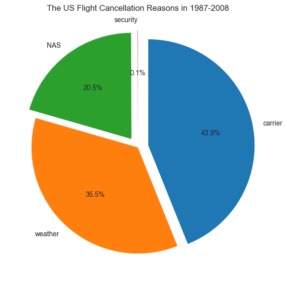

```python
# figure
plt.figure(figsize=[7, 7])

cancel_codes = df["CancellationCode"].value_counts()

# A = carrier, B = weather, C = NAS, D = security
cancel_labels = ['carrier', 'weather', 'NAS', 'security']

# display percentages on the pie plot
plt.pie(cancel_codes, labels=cancel_labels, startangle=90, counterclock=False, autopct='%1.1f%%',
        explode=(0.1, 0, 0.1, 0.1),
        wedgeprops = {"edgecolor" : "white",
                      'linewidth': 0,
                      'antialiased': True})

# title and labels
plt.title("The US Flight Cancellation Reasons in 1987-2008");
```

### Observation

> The most common reason for flight cancellation was carrier, the second most common being weather, followed by NAS, and only in a few cases security.

### Of the features you investigated, were there any unusual distributions? Did you perform any operations on the data to tidy, adjust, or change the form of the data? If so, why did you do this?

> There were many negative values in the delay time columns which indicated potential earlier arrivals/departures. There were several outliers that exceeded 1000 minutes in both cases. Therefore, changing the axis tick limits also helped.

## Bivariate Exploration

> In this section, relationships between pairs of variables in the data were investigated.

### Question #6

> How did the average distance passed by flights change over the period?

### Visualisation

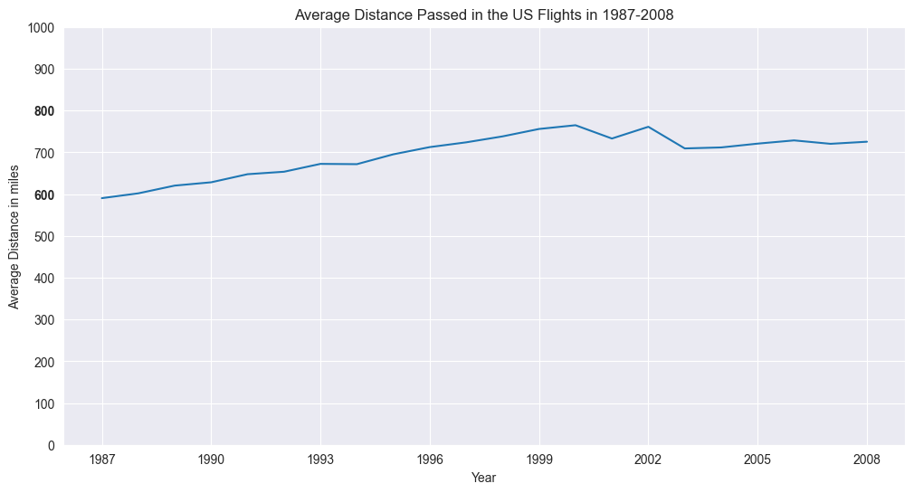

```python
# group by Year and find the mean distance passed
year_distance = df.groupby("Year")["Distance"].mean()

# set the figure size
plt.figure(figsize=(12, 6))

# plot a line chart
plt.plot(year_distance.index, year_distance.values)

plt.title("Average Distance Passed in the US Flights in 1987-2008")
plt.xlabel("Year")
plt.ylabel("Average Distance in miles")

# set tick values and names
xtick_values = np.arange(1987, 2009, 3)
xtick_names = [str(value) for value in xtick_values]

# apply changes
plt.xticks(xtick_values, xtick_names)

# set tick values and names
ytick_values = np.arange(0, 1000 + 100, 100)
ytick_names = [str(value) for value in ytick_values]

# apply changes
plt.yticks(ytick_values, ytick_names)

plt.gca().get_yticklabels()[6].set_fontweight('bold')
plt.gca().get_yticklabels()[8].set_fontweight('bold');
```

### Observation

> We can see from the line chart that the average distance passed through flights increased consistently between 1987 and early 2000's.

> The peak values were detected between the years 2000 and 2002.

### Question #7

> What is the relationship between the delay types and their corresponding minutes?

### Visualisation

```python
# use the melt function to get columns for delay types and their corresponding latency minutes
delay_types = df.melt(id_vars=['Year'],
                      value_vars=['CarrierDelay', 'WeatherDelay', 'NASDelay', 'SecurityDelay', 'LateAircraftDelay'],
                      var_name="delay_type",
                      value_name="delay_minutes")

delay_types['delay_minutes'] = delay_types['delay_minutes'].apply(lambda x: x if x!= 0.0 else np.nan)
delay_types.dropna(inplace=True)
```

```python
# function to avoid repeating the label names and tick values
def common_attributes():
    plt.title("1987-2008 US flights Time Offset Distribution with Log scaling")
    plt.xlabel("Delay Type")
    plt.ylabel("Earliness Time Offset                     Delay Time Offset in minutes")

    plt.yscale("symlog")

    plt.axhline(0, color='red')

    ytick_values = [-10, -3, -1, 0, 1, 2, 5, 10, 30, 100, 1000, 2400]
    ytick_names = [str(value) for value in ytick_values]

    plt.yticks(ytick_values, ytick_names)
```

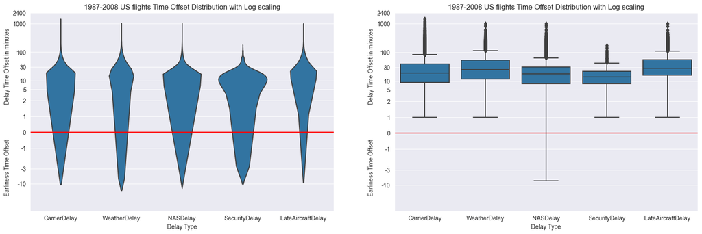

```python
plt.figure(figsize=(20, 6))

# Subplot 1: Violin plot with log scaling
plt.subplot(1, 2, 1)
sb.violinplot(data=delay_types, x='delay_type', y='delay_minutes', color=base_color, inner=None)

common_attributes()

# Subplot 2: Box plot
plt.subplot(1, 2, 2)
sb.boxplot(data=delay_types, x='delay_type', y='delay_minutes', color=base_color)

common_attributes();
```

### Observation

> Moreover, weather and late aircraft delays were the ones with the highest delay minutes.

> Due to the NAS, some flights had to arrive as early as about 10 minutes.

### Question #8

> What is the relationship between the departure and arrival time offsets (earliness and delay)?

### Visualisation

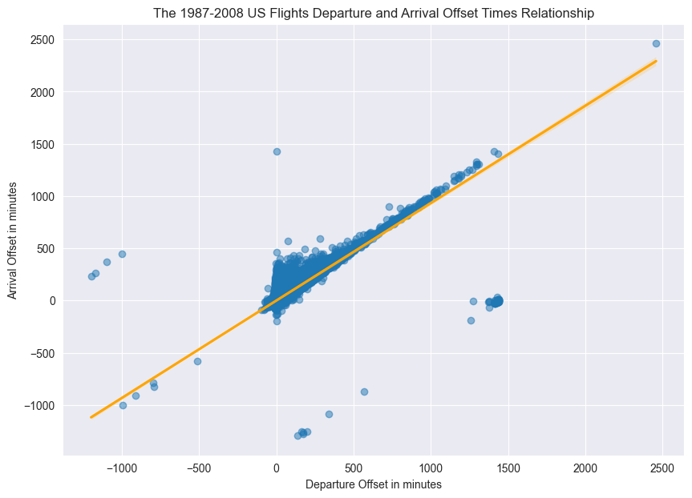

```python
plt.figure(figsize=(10, 7))

sb.regplot(data=df, x='DepDelay', y='ArrDelay', scatter_kws={"alpha": 0.5}, line_kws={"color": "orange"})

plt.title("The 1987-2008 US Flights Departure and Arrival Offset Times Relationship")
plt.xlabel("Departure Offset in minutes")
plt.ylabel("Arrival Offset in minutes");
```

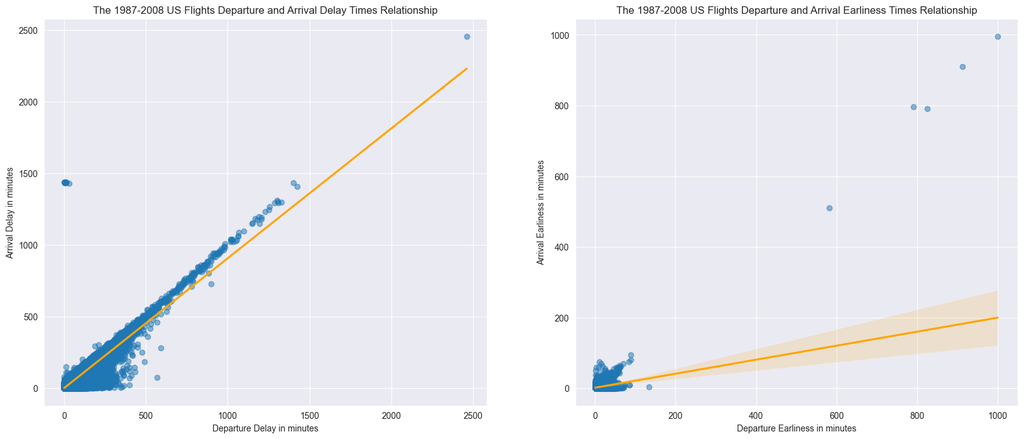

```python
plt.figure(figsize=(20, 8))

plt.subplot(1, 2, 1)

# positive minutes
positive_dep_delay = df["DepDelay"].apply(lambda x: x if x > 0 else np.nan)
positive_arr_delay = df["ArrDelay"].apply(lambda x: x if x > 0 else np.nan)

# regression plot
sb.regplot(x=positive_arr_delay, y=positive_dep_delay, scatter_kws={"alpha": 0.5}, line_kws={"color": "orange"})

# title and labels
plt.title("The 1987-2008 US Flights Departure and Arrival Delay Times Relationship")
plt.xlabel("Departure Delay in minutes")
plt.ylabel("Arrival Delay in minutes")

plt.subplot(1, 2, 2)

# negative minutes: early departure & arrival
negative_dep_delay = df["DepDelay"].apply(lambda x: abs(x) if x < 0 else np.nan)
negative_arr_delay = df["ArrDelay"].apply(lambda x: abs(x) if x < 0 else np.nan)

# regression plot
sb.regplot(x=negative_arr_delay, y=negative_dep_delay, scatter_kws={"alpha": 0.5}, line_kws={"color": "orange"})
plt.title("The 1987-2008 US Flights Departure and Arrival Earliness Times Relationship")
plt.xlabel("Departure Earliness in minutes")
plt.ylabel("Arrival Earliness in minutes");
```

### Observation

> According to the scatter plots obtained, we can say that departure and arrival delays have a linear relationship. Most of the time, departure delays equivalently impacted the arrival time.

> It is also worth noting that when plotted together, both earliness and tardiness minutes formed an almost perfect regression line. However, the linear model had a different slope on the earliness one when plotted separately.

### Question #9

> What is the relationship between the travel distance and the air time?

### Visualisation

```python
def common_attributes():
    # title and labels
    plt.title("The 1987-2008 US Flights Travel Distance and Air Time Relationship")
    plt.xlabel("Distance in miles")
    plt.ylabel("Air Time in minutes")

    # set tick values and names
    xtick_values = np.arange(0, 5000, 500)
    xtick_names = [str(value) for value in xtick_values]

    # apply changes
    plt.xticks(xtick_values, xtick_names)
```

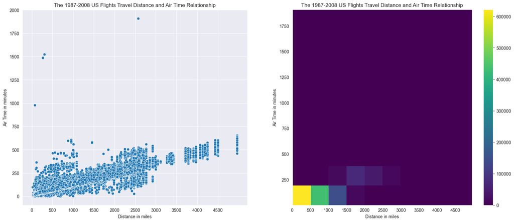

```python
distance_airtime = df[["Distance", "AirTime"]].dropna().query("AirTime > 0")

plt.figure(figsize=(20, 8))

#subplot 1: Scatter Plot
plt.subplot(1, 2, 1)
sb.scatterplot(data=distance_airtime, x="Distance", y="AirTime")

common_attributes()

# subplot 2: heatmap
plt.subplot(1, 2, 2)
plt.hist2d(x=distance_airtime["Distance"], y=distance_airtime["AirTime"], cmap="viridis")

# show the colour map
plt.colorbar()

common_attributes();
```

### Observation

> We can see from the plots that most flights had the distances of less than 1000 miles and the air time of about 200 minutes.

## Multivariate Exploration

> In this section, relationships between three variables were investigated to gain more insights from the data.

### Question #10

> What is the distribution of delay minutes according to their types on the yearly basis?

### Visualisation

```python
delay_types.head()
```

|  | Year | delay_type | delay_minutes |
| --- | --- | --- | --- |
| 1600014 | 2003 | CarrierDelay | 26.0 |
| 1600122 | 2003 | CarrierDelay | 218.0 |
| 1600127 | 2003 | CarrierDelay | 45.0 |
| 1600164 | 2003 | CarrierDelay | 28.0 |
| 1600167 | 2003 | CarrierDelay | 5.0 |

```python
delay_types.groupby(["Year", "delay_type"])["delay_minutes"].mean()
```

```
Year  delay_type
2003  CarrierDelay         35.157487
      LateAircraftDelay    40.409823
      NASDelay             28.112458
      SecurityDelay        25.571429
      WeatherDelay         45.348160
2004  CarrierDelay         32.776775
      LateAircraftDelay    41.614757
      NASDelay             27.648571
      SecurityDelay        17.983333
      WeatherDelay         42.529070
2005  CarrierDelay         32.429371
      LateAircraftDelay    41.693875
      NASDelay             27.171037
      SecurityDelay        21.809091
      WeatherDelay         43.856675
2006  CarrierDelay         33.102164
      LateAircraftDelay    44.246148
      NASDelay             27.006688
      SecurityDelay        19.312000
      WeatherDelay         43.715517
2007  CarrierDelay         35.775926
      LateAircraftDelay    45.274357
      NASDelay             27.118529
      SecurityDelay        19.120301
      WeatherDelay         45.135392
2008  CarrierDelay         35.542449
      LateAircraftDelay    44.613545
      NASDelay             27.348728
      SecurityDelay        15.857143
      WeatherDelay         44.254805
Name: delay_minutes, dtype: float64
```

```python
# function to avoid repeating the label names and tick values
def common_attributes():
    plt.title("2003-2008 US Flights Delay Types Yearly Distribution")
    plt.xlabel("Year")
```

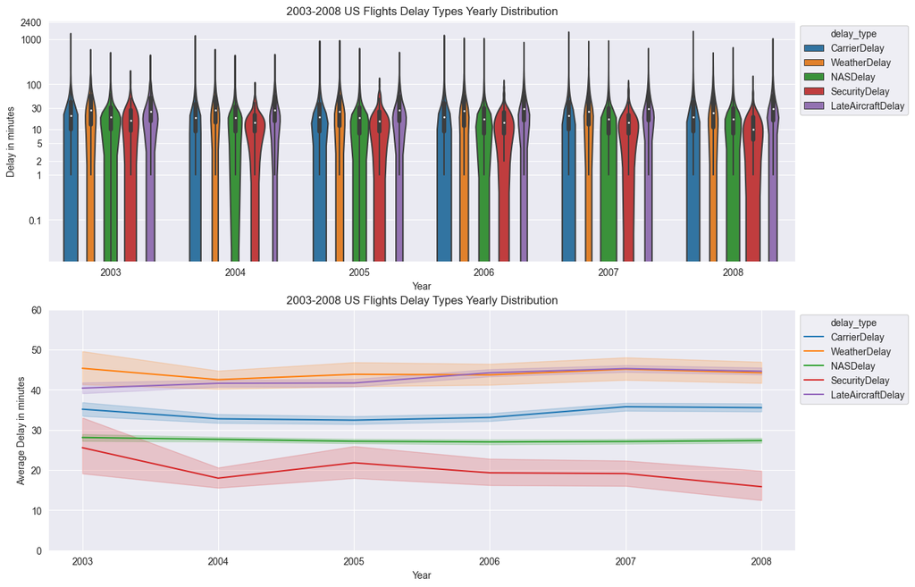

```python
# figure
plt.figure(figsize=(14, 10))

# subplot 1: violin plot
plt.subplot(2, 1, 1)
ax = sb.violinplot(data=delay_types, x="Year", y="delay_minutes", hue="delay_type")

plt.ylabel("Delay in minutes")
# set the legend position
sb.move_legend(ax, "upper left", bbox_to_anchor=(1, 1))

common_attributes()

# apply scaling
plt.yscale("log")

ytick_values = [0.1, 1, 2, 5, 10, 30, 100, 1000, 2400]
ytick_names = [str(value) for value in ytick_values]

plt.yticks(ytick_values, ytick_names)

# subplot 2: line plot
plt.subplot(2, 1, 2)
ax = sb.lineplot(data=delay_types, x="Year", y="delay_minutes", hue="delay_type")
sb.move_legend(ax, "upper left", bbox_to_anchor=(1, 1))

plt.ylabel("Average Delay in minutes")

# apply axis limits
plt.ylim(0, 60)

common_attributes();
```

### Question #11

> How does the average delay time vary along the scheduled arrival and departure hours?

### Visualisation

```python
from datetime import time

# custom function
def convert_datetime(str_time: float):
    if pd.isna(str_time):
        return
    str_time = str(round(str_time))
    if len(str_time) == 4:
        hour = str_time[:2]
        minutes = str_time[2:4]
        if int(hour) > 23:
            return np.nan
        hour_minute = time(hour=int(hour), minute=int(minutes))
    elif len(str_time) == 3:
        hour = str_time[:1]
        minutes = str_time[2:3]
        if int(hour) > 23:
            return np.nan
        hour_minute = time(hour=int(hour), minute=int(minutes))
    elif len(str_time) == 2:
        hour = str_time[0]
        minutes = str_time[1]
        if int(hour) > 23:
            return np.nan
        hour_minute = time(hour=int(hour), minute=int(minutes))
    else:
        hour_minute = np.nan
    return hour_minute
```

```python
# apply the function and change the corresponding data types into datetime
df["DepTime"] = pd.to_datetime(df["DepTime"].apply(convert_datetime), format='%H:%M:%S')
df["ArrTime"] = pd.to_datetime(df["ArrTime"].apply(convert_datetime), format='%H:%M:%S')
```

```python
df["CRSDepTime"] = pd.to_datetime(df["CRSDepTime"].apply(convert_datetime), format='%H:%M:%S')
df["CRSArrTime"] = pd.to_datetime(df["CRSArrTime"].apply(convert_datetime), format='%H:%M:%S')
```

```python
# use the melt function to get columns for delay types and their corresponding latency minutes
delay_time_types = df.melt(id_vars=['DepDelay', 'ArrDelay'],
                      value_vars=['CRSDepTime', 'CRSArrTime'],
                      var_name="flight_time_type",
                      value_name="time")

delay_time_types['mean_delay'] = (delay_time_types['DepDelay'] + delay_time_types['ArrDelay']) / 2
```

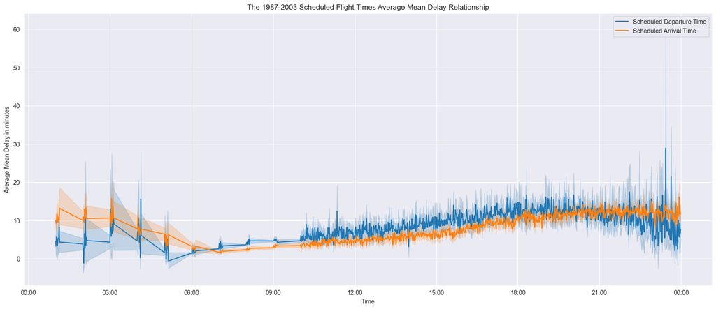

```python
from matplotlib.dates import DateFormatter

#  figure
plt.figure(figsize=(20, 8))

# line plot with classified into types
ax = sb.lineplot(data=delay_time_types, x="time", y="mean_delay", hue="flight_time_type")

# change label names
labels = plt.legend()
labels.get_texts()[0].set_text("Scheduled Departure Time")
labels.get_texts()[1].set_text("Scheduled Arrival Time")

# labels and titles

plt.title("The 1987-2003 Scheduled Flight Times Average Mean Delay Relationship")
plt.xlabel("Time")
plt.ylabel("Average Mean Delay in minutes")

# reformat ticks as HH:MM
hh_mm = DateFormatter('%H:%M')
ax.xaxis.set_major_formatter(hh_mm);
```

### Observation

> We can see from the line plot that both scheduled arrival and departure hours had similar values in regard to the average mean delay time. The delay minutes seemed to have increased during the later hours.

### Talk about some of the relationships you observed in this part of the investigation. Were there features that strengthened each other in terms of looking at your feature(s) of interest?

> We could get more insights regarding delay times using the specific hours of the day. Moreover, we could see a rather stable trend of average delay times in category-based analysis.

## Conclusions

> One of the main focuses of the exploration was towards the flight delays and their relationships with other essential features.

> In terms of relationships between arrival and departure delays, most of the time, departure delays equivalently impacted the arrival time. The average delay time of the flights among the categories almost remained stable during the period.

> In many cases, the logarithmic scaling had to be performed due to the large number of outliers.